# MPM03 - Toolbox with RMarkdown

**What we get? (Interpretation)**

- Due to the loop, we get different Dendrograms and correlation matrices (with difference distance methods)
- The results for the Dendrograms are similar like in the Dendrograms above: GK-observations are quite similar to each other and are a good separator for splitting the predictors into groups. The same statement we can make for the defending-predictors like Interceptions, Sliding Tackle and Standing Tackle and for the attacking-predictors like Volley, ShootPower, Penalties and Finishing.
- Thanks to the Factoextra Package, we can also create nice correlation matrices. The matrices help to visualize in a convenient way, how the different features relate to each other.
- The presumptions we have from the Dendrograms can be displayed very clearly: very strong correlation in GK-skills, strong correlation in Defender-Skills (Interceptions, Sliding Tackle and Standing Tackle) and for the attacking-features like Volley, ShootPower, Penalties and Finishing.
- What is also visible is the high correlation between ball control, dribbling, skill moves and agility and negative correlations between GK skills and completion skills (shot power, volleys, etc.).
- Overall, we can say that the main findings from the different distance methods (type of metric, which is responsible to build homogeneous subgroups, e.g. Euclidean, manhattan, minkowski) are similar.

#### Extended Heatmap with color brewer

**What we do? (Code)**

We make a new color code and do a row-and column-wise clustering with individual linkage and distance method. Headmap.2 allows to define linkage & distance methods for heatmap representation.

Note: brewer.pal(n, name), n = Number of different colors in the palette, minimum 3, maximum depending on palette, name = Blues BuGn BuPu GnBu Greens Greys Oranges OrRd PuBu PuBuGn PuRd Purples RdPu Reds YlGn YlGnBu YlOrBr YlOrRd

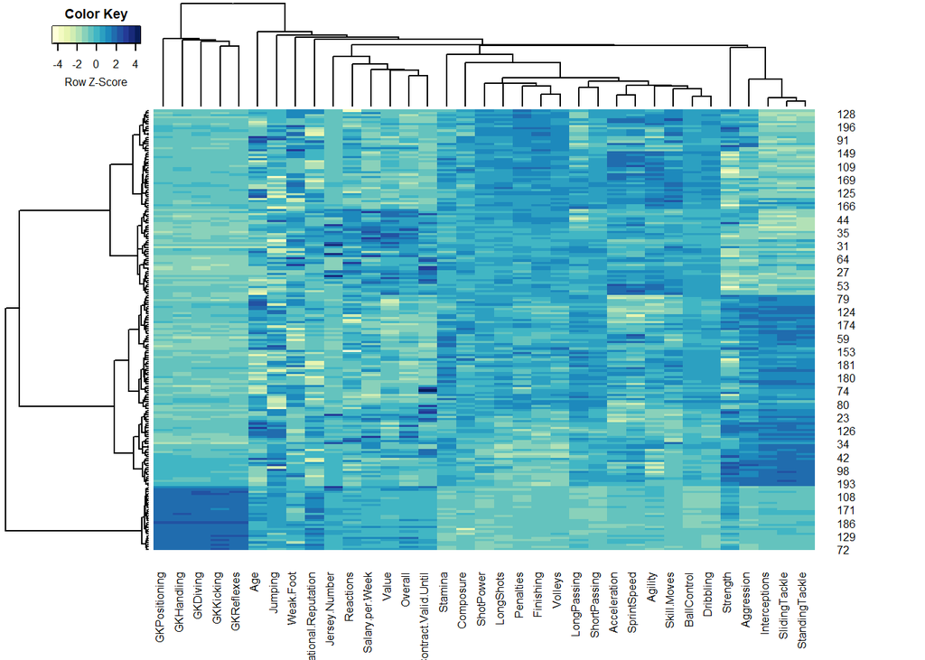

```r
palette <- colorRampPalette(brewer.pal(9, "YlGnBu"))

hc1 <- hclust(as.dist(1-cor(t_scaled_data, method="kendall")), method="ward.D")
hc2 <- hclust(as.dist(1-cor(scaled_data, method="spearman")), method="single")

heatmap.2(scaled_data,
          Rowv=as.dendrogram(hc1),
          Colv=as.dendrogram(hc2),
          col=palette,
          cexRow = 0.6,
          cexCol = 0.6,
          keysize = 0.8,
          key.par = list(cex=0.5),
          scale="row",
          density.info="none", trace="none")
```

**What we get? (Interpretation)**

- Similar results like with Heatmap in R-Standard, but color-key-legend visible and new color-code.

## **LESSON 03 / 04.10.2019**

### PRINCIPAL COMPONENT ANALYSIS (PCA)

When faced with a large set of correlated variables, principal components allow us to summarize this set with a smaller number of representative variables that collectively explain most of the variability in the original set.

**Description:**

- Unsupervised
- Non-Parametric
- Linear

**Functionality:**

- Reduces the dimensionality of a dataset and leads to a more understandable representation (Data organization method for grouping variables with similar behaviour)
- Push the data into K pre-determined categories
  - Find new axes (principal components) that represent the data space in a reduced set of dimensions (capture the most important information in the data)
  - Capture the maximal variance of the data
  - Highlight the global patterns in the data set

**Aim:**

- First exploration of multidimensional data (no assumptions needed)

**Fields of application:**

- Market segmentation
- Medical examination (e.g. tumour detection)

**Further information:**

- Difference between PCA and HC
  - Compared to HC, PCA projects multi-dimensional data on a low-dimensional space that best summarizes data variance
  - HC makes homogeneous subgroups of data that have similarities based on a distance metric

#### PCA Starplots

**What we do? (Code)**

We use a sample of 20 rows and reduce the number of dimensions to 6, so that we can have a look at some starplots.

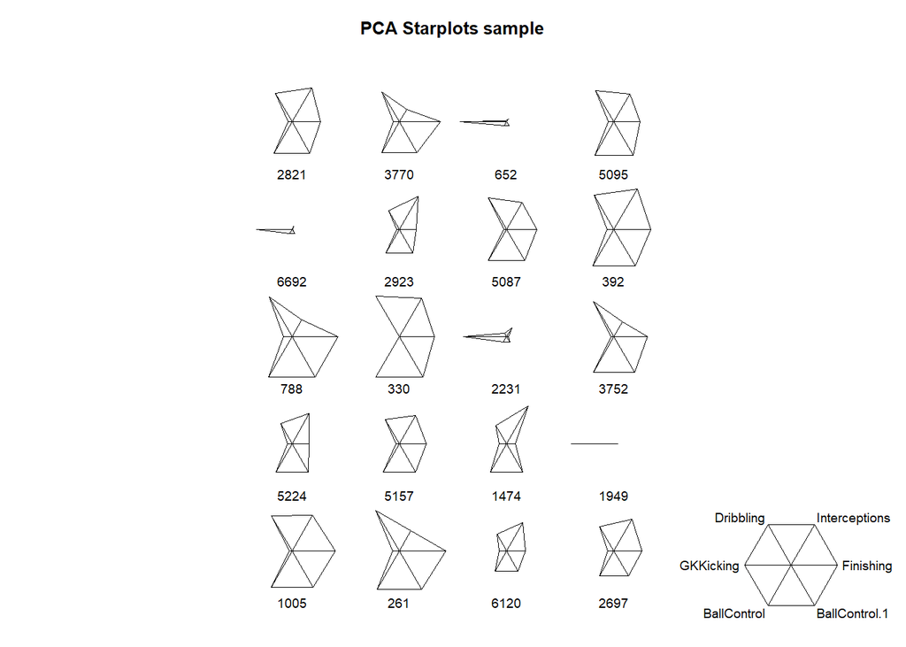

```r
set.seed(3)

N <- nrow(data_only_numerical)
id.sample_data <- sample(1:N, size = 20, replace = FALSE)

stars(data_only_numerical[id.sample_data,floor(runif(6,1,20))],
      main = "PCA Starplots sample",
      key.loc = c(13,2),
      cex = 0.6,
      cex.main = 0.8)
```

**What we get? (Interpretation)**

#### PCA Fit, PCA Summary & Screeplot

**What we do? (Code)**

Now, we perform principal components analysis using the prcomp() function, which is one of several functions in R that perform PCA. PCA tries to find new axes (principal components) that represent the data space in a reduced set of dimensions that capture the most important information.

```r
pca.data <-prcomp(scaled_data)
names(pca.data)
```

```
[1] "sdev"     "rotation" "center"   "scale"    "x"
```

```r
#pca.data$center
#pca.data$scale
#pca.data$rotation
summary(pca.data)
```

```
Importance of components:
                         PC1   PC2    PC3    PC4    PC5   PC6    PC7
Standard deviation     4.134 2.301 1.8438 1.2841 1.1766 1.092 0.8077
Proportion of Variance 0.488 0.151 0.0971 0.0471 0.0396 0.034 0.0186
Cumulative Proportion  0.488 0.639 0.7366 0.7837 0.8233 0.857 0.8760
                          PC8    PC9  PC10   PC11    PC12   PC13    PC14
Standard deviation     0.7574 0.7337 0.701 0.6603 0.56975 0.5455 0.53751
Proportion of Variance 0.0164 0.0154 0.014 0.0125 0.00927 0.0085 0.00825
Cumulative Proportion  0.8923 0.9077 0.922 0.9342 0.94350 0.9520 0.96025
                          PC15    PC16  PC17   PC18    PC19   PC20   PC21
Standard deviation     0.44855 0.42749 0.418 0.3548 0.35034 0.3186 0.3074
Proportion of Variance 0.00575 0.00522 0.005 0.0036 0.00351 0.0029 0.0027
Cumulative Proportion  0.96600 0.97122 0.976 0.9798 0.98332 0.9862 0.9889
                          PC22    PC23    PC24    PC25    PC26   PC27
Standard deviation     0.24872 0.21723 0.20722 0.18949 0.18444 0.1774
Proportion of Variance 0.00177 0.00135 0.00123 0.00103 0.00097 0.0009
Cumulative Proportion  0.99069 0.99204 0.99327 0.99429 0.99526 0.9962
                          PC28    PC29    PC30    PC31    PC32    PC33
Standard deviation     0.16029 0.15224 0.14249 0.13570 0.12237 0.11202
Proportion of Variance 0.00073 0.00066 0.00058 0.00053 0.00043 0.00036
Cumulative Proportion  0.99690 0.99756 0.99814 0.99867 0.99909 0.99945
                         PC34    PC35
Standard deviation     0.1019 0.09385
Proportion of Variance 0.0003 0.00025
Cumulative Proportion  0.9998 1.00000
```

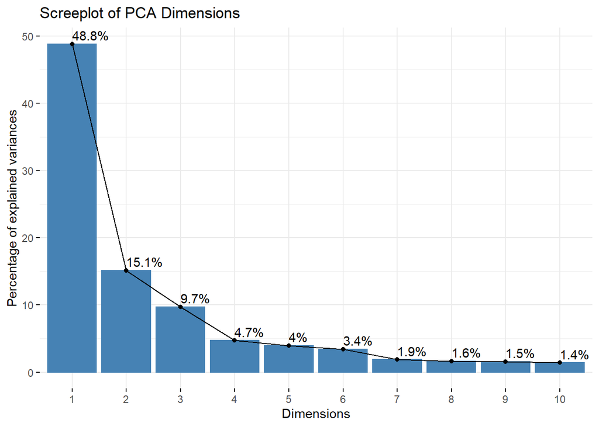

```r
fviz_eig(pca.data,
         width=0.8,
         addlabels=TRUE,
         main = "Screeplot of PCA Dimensions",
         cex = 0.8,
         cex.main = 0.8)
```

**What we get? (Interpretation)**

- The output from prcomp() contains a number of useful quantities. The center and scale components correspond to the means and standard deviations of the variables that were used for scaling prior to implementing PCA. The rotation matrix provides the principal component loadings; each column of pr.out$rotation contains the corresponding principal component loading vector.
- The Screeplot describes the proportion of variance explained by each of the components in the data set. In the example above, the first principal component explains 48.8% of the variance and the second additional 15.1%. The standard deviation, the proportion of variance (per component) and the cumulative proportion can also be looked up with the summary-function.

#### PCA Biplot

**What we do? (Code)**

We display now the two first components. But first we need to reduce the amount of values.

```r
set.seed(5)

id.sample_data2 <- sample(1:N, size = 50, replace = FALSE)
scaled_data2 <- scale(data_only_numerical[id.sample_data2,floor(runif(10,1,30))])
pca.data2 <-prcomp(scaled_data2)
summary(pca.data2)
```

```
Importance of components:
                         PC1   PC2   PC3    PC4    PC5    PC6
Standard deviation     2.192 1.587 1.207 0.8825 0.5501 0.3707
Proportion of Variance 0.481 0.252 0.146 0.0779 0.0303 0.0138
Cumulative Proportion  0.481 0.732 0.878 0.9560 0.9862 1.0000
                                        PC7                  PC8
Standard deviation     0.000000000000000222 0.000000000000000135
Proportion of Variance 0.000000000000000000 0.000000000000000000
Cumulative Proportion  1.000000000000000000 1.000000000000000000
                                        PC9                  PC10
Standard deviation     0.000000000000000066 0.0000000000000000222
Proportion of Variance 0.000000000000000000 0.0000000000000000000
Cumulative Proportion  1.000000000000000000 1.0000000000000000000
```

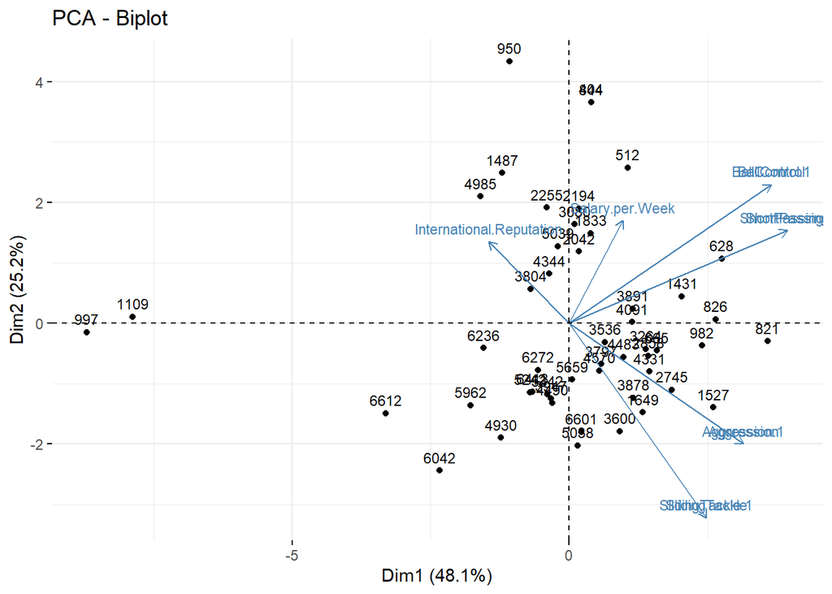

```r
fviz_pca_biplot(pca.data2, labelsize = 3)
```

**What we get? (Interpretation)**

### T-DISTRIBUTED STOCHASTIC NEIGHBOR EMBEDDING (tSNE)

t-Distributed Stochastic Neighbor Embedding (tSNE) is a non-linear technique for dimensionality reduction that is particularly well suited for the visualization of high-dimensional datasets.

**Description:**

- Unsupervised
- Non-Parametric
- Non-Linear

**Functionality:**

- Embeds high-dimensional data in a low-dimensional space to visualize (Data organization method for grouping variables with similar behaviour)
- tSNE minimizes the difference between the similarity of points in high & in low-dimensional space (according to a conditional probability ruled by a probability distribution)
- Minimize distributions divergence (Kullback-Leibler divergence, relative entropy) between
  - a similarity distribution of multi-dimensional input objects and
  - a similarity distribution of the corresponding low-dimensional points
  - using a gradient descent

**Aim:**

- Exploration & visualization of data, well-suited for high-dimensional data

**Fields of application:**

- Market segmentation
- Medical examination (e.g. tumour detection)
- –> sometimes tSNE can better separate groups than PCA and HC, especially in higher dimensions

**Further information:**

- Difference between tSNE (2008) and PCA (1933)
  - Compared to PCA, tSNE transforms the data via a non-linear operation based on Gaussian / t-distributions
  - PCA projects multi-dimensional data on a low-dimensional space (linear mapping of the data to a low-dimensional space such that variance is maximized)
  - tSNE should be more effective than PCA, capturing more information from the high-dimensional space

#### t-Distributed Stochastic Neighbor Embedding **with** labelling

**What we do? (Code)**

We use the tSNE-Method for the visualization of a high-dimensional dataset.

```r
set.seed(4)

row_label <- as.factor(rownames(selection_data_only_numerical))
colors <- c("red", "black", "blue", "green")
colors <- colors[as.numeric(data_categorical_variable)]

tsne <- Rtsne(data_unique2,
              dims = 2,
              perplexity=10,
              verbose=TRUE,
              max_iter = 500)
```

```
Performing PCA
Read the 196 x 35 data matrix successfully!
OpenMP is working. 1 threads.
Using no_dims = 2, perplexity = 10.000000, and theta = 0.500000
Computing input similarities...
Building tree...
Done in 0.01 seconds (sparsity = 0.198719)!
Learning embedding...
Iteration 50: error is 63.263612 (50 iterations in 0.02 seconds)
Iteration 100: error is 61.046367 (50 iterations in 0.02 seconds)
Iteration 150: error is 62.997417 (50 iterations in 0.03 seconds)
Iteration 200: error is 62.537887 (50 iterations in 0.03 seconds)
Iteration 250: error is 61.855195 (50 iterations in 0.03 seconds)
Iteration 300: error is 1.261720 (50 iterations in 0.02 seconds)
Iteration 350: error is 0.843627 (50 iterations in 0.02 seconds)
Iteration 400: error is 0.811341 (50 iterations in 0.02 seconds)
Iteration 450: error is 0.786846 (50 iterations in 0.02 seconds)
Iteration 500: error is 0.780560 (50 iterations in 0.02 seconds)
Fitting performed in 0.21 seconds.
```

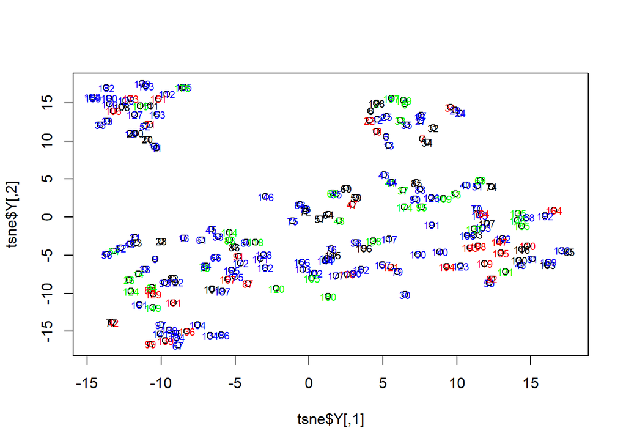

```r
plot(tsne$Y)
text(tsne$Y,
     labels=row_label,
     col=colors[row_label],
     cex = 0.7)
```

**What we get? (Interpretation)**

- In the interpretation of tsne-Plots, we only can learn the way groups are made. Distances have (almost) no meaning.
- In the tsne-Plot above, the groups seem to overlap. No clear structure is visible.
- In the next chapters, we try to adjust the parameters to get better results.

#### t-Distributed Stochastic Neighbor Embedding higher perplexity

**What we do? (Code)**

We try to get better results by changing the perplexity. The perplexity measures the numbers of close neighbors of each point. A higher perplexity means a data point will consider more points as its close neighbors.

```
Performing PCA
Read the 196 x 35 data matrix successfully!
OpenMP is working. 1 threads.
Using no_dims = 2, perplexity = 2.000000, and theta = 0.500000
Computing input similarities...
Building tree...
Done in 0.01 seconds (sparsity = 0.044929)!
Learning embedding...
Iteration 50: error is 80.904180 (50 iterations in 0.03 seconds)
Iteration 100: error is 80.122856 (50 iterations in 0.02 seconds)
Iteration 150: error is 73.903999 (50 iterations in 0.02 seconds)
Iteration 200: error is 72.388285 (50 iterations in 0.02 seconds)
Iteration 250: error is 71.025141 (50 iterations in 0.02 seconds)
Iteration 300: error is 2.532484 (50 iterations in 0.02 seconds)
Iteration 350: error is 1.576922 (50 iterations in 0.02 seconds)
Iteration 400: error is 1.058949 (50 iterations in 0.02 seconds)
Iteration 450: error is 0.887592 (50 iterations in 0.02 seconds)
Iteration 500: error is 0.849761 (50 iterations in 0.02 seconds)
Fitting performed in 0.20 seconds.
```

```
Performing PCA
Read the 196 x 35 data matrix successfully!
OpenMP is working. 1 threads.
Using no_dims = 2, perplexity = 5.000000, and theta = 0.500000
Computing input similarities...
Building tree...
Done in 0.01 seconds (sparsity = 0.105945)!
Learning embedding...
Iteration 50: error is 71.725900 (50 iterations in 0.03 seconds)
Iteration 100: error is 68.426470 (50 iterations in 0.04 seconds)
Iteration 150: error is 68.057026 (50 iterations in 0.03 seconds)
Iteration 200: error is 67.042162 (50 iterations in 0.02 seconds)
Iteration 250: error is 68.105649 (50 iterations in 0.02 seconds)
Iteration 300: error is 2.105988 (50 iterations in 0.02 seconds)
Iteration 350: error is 1.311553 (50 iterations in 0.02 seconds)
Iteration 400: error is 1.130872 (50 iterations in 0.02 seconds)
Iteration 450: error is 1.025135 (50 iterations in 0.02 seconds)
Iteration 500: error is 0.944899 (50 iterations in 0.02 seconds)
Fitting performed in 0.24 seconds.
```

```
Performing PCA
Read the 196 x 35 data matrix successfully!
OpenMP is working. 1 threads.
Using no_dims = 2, perplexity = 10.000000, and theta = 0.500000
Computing input similarities...
Building tree...
Done in 0.01 seconds (sparsity = 0.198719)!
Learning embedding...
Iteration 50: error is 64.236450 (50 iterations in 0.02 seconds)
Iteration 100: error is 62.753693 (50 iterations in 0.03 seconds)
Iteration 150: error is 61.749238 (50 iterations in 0.03 seconds)
Iteration 200: error is 62.951195 (50 iterations in 0.02 seconds)
Iteration 250: error is 62.738701 (50 iterations in 0.02 seconds)
Iteration 300: error is 1.556268 (50 iterations in 0.02 seconds)
Iteration 350: error is 0.930711 (50 iterations in 0.02 seconds)
Iteration 400: error is 0.799499 (50 iterations in 0.02 seconds)
Iteration 450: error is 0.786085 (50 iterations in 0.02 seconds)
Iteration 500: error is 0.769403 (50 iterations in 0.02 seconds)
Fitting performed in 0.21 seconds.
```

```
Performing PCA
Read the 196 x 35 data matrix successfully!
OpenMP is working. 1 threads.
Using no_dims = 2, perplexity = 20.000000, and theta = 0.500000
Computing input similarities...
Building tree...
Done in 0.02 seconds (sparsity = 0.404623)!
Learning embedding...
Iteration 50: error is 54.387890 (50 iterations in 0.02 seconds)
Iteration 100: error is 54.582225 (50 iterations in 0.03 seconds)
Iteration 150: error is 55.552957 (50 iterations in 0.03 seconds)
Iteration 200: error is 54.966585 (50 iterations in 0.03 seconds)
Iteration 250: error is 57.463877 (50 iterations in 0.03 seconds)
Iteration 300: error is 0.969628 (50 iterations in 0.02 seconds)
Iteration 350: error is 0.531318 (50 iterations in 0.02 seconds)
Iteration 400: error is 0.520543 (50 iterations in 0.03 seconds)
Iteration 450: error is 0.518324 (50 iterations in 0.02 seconds)
Iteration 500: error is 0.517532 (50 iterations in 0.02 seconds)
Fitting performed in 0.25 seconds.
```

```
Performing PCA
Read the 196 x 35 data matrix successfully!
OpenMP is working. 1 threads.
Using no_dims = 2, perplexity = 30.000000, and theta = 0.500000
Computing input similarities...
Building tree...
Done in 0.05 seconds (sparsity = 0.599594)!
Learning embedding...
Iteration 50: error is 50.806896 (50 iterations in 0.03 seconds)
Iteration 100: error is 52.458665 (50 iterations in 0.03 seconds)
Iteration 150: error is 52.685742 (50 iterations in 0.03 seconds)
Iteration 200: error is 51.032296 (50 iterations in 0.03 seconds)
Iteration 250: error is 51.217860 (50 iterations in 0.03 seconds)
Iteration 300: error is 0.594841 (50 iterations in 0.02 seconds)
Iteration 350: error is 0.415940 (50 iterations in 0.02 seconds)
Iteration 400: error is 0.410045 (50 iterations in 0.02 seconds)
Iteration 450: error is 0.402593 (50 iterations in 0.02 seconds)
Iteration 500: error is 0.399004 (50 iterations in 0.02 seconds)
Fitting performed in 0.24 seconds.
```

```
Performing PCA
Read the 196 x 35 data matrix successfully!
OpenMP is working. 1 threads.
Using no_dims = 2, perplexity = 50.000000, and theta = 0.500000
Computing input similarities...
Building tree...
Done in 0.07 seconds (sparsity = 0.909621)!
Learning embedding...
Iteration 50: error is 47.244037 (50 iterations in 0.03 seconds)
Iteration 100: error is 46.150274 (50 iterations in 0.03 seconds)
Iteration 150: error is 46.338905 (50 iterations in 0.03 seconds)
Iteration 200: error is 46.775895 (50 iterations in 0.03 seconds)
Iteration 250: error is 47.162190 (50 iterations in 0.03 seconds)
Iteration 300: error is 0.332792 (50 iterations in 0.02 seconds)
Iteration 350: error is 0.284765 (50 iterations in 0.02 seconds)
Iteration 400: error is 0.283571 (50 iterations in 0.02 seconds)
Iteration 450: error is 0.285615 (50 iterations in 0.02 seconds)
Iteration 500: error is 0.286742 (50 iterations in 0.02 seconds)
Fitting performed in 0.27 seconds.
```

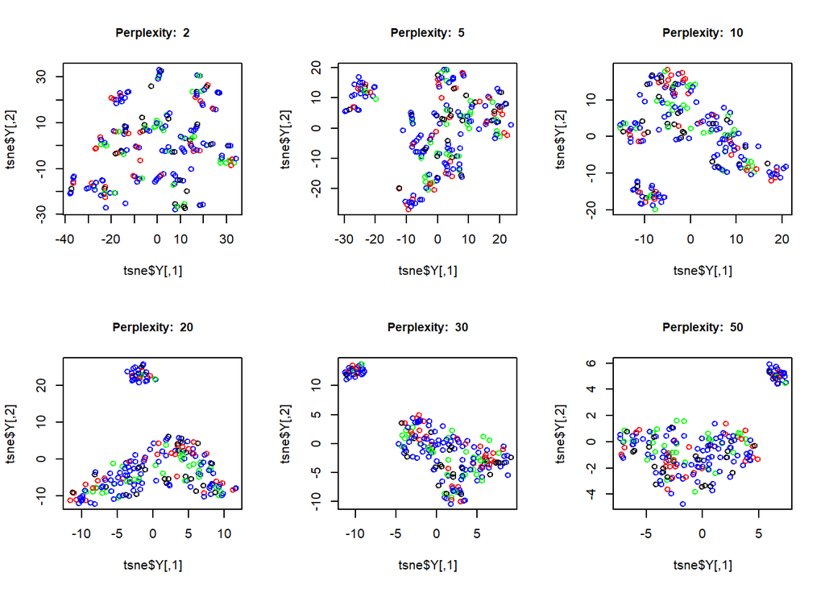

```r
set.seed(17)

par(mfrow=c(2,3))

perplexity_choice <- c(2, 5, 10, 20, 30, 50)

for (i in perplexity_choice){
  tsne <- Rtsne(data_unique2,
                dims = 2,
                perplexity=i,
                verbose=TRUE,
                max_iter = 500)
  plot(tsne$Y,
       main = paste("Perplexity: ", i),
       col=colors[row_label],
       cex = 0.9,
       cex.main = 0.9)
}
```

**What we get? (Interpretation)**

- The loop-function generates several tsne-plots with different levels of perplexity (e.g. 2, 5, 10, 20, 30, 50)
- As described above, a higher perplexity means a data point will consider more points as its close neighbors.
- With low perplexity, no groups are visible (overlapping).
- With perplexity = 30 we can recognize a group at the top of the plot, which consists mainly of blue data points.

#### t-Distributed Stochastic Neighbor Embedding higher number of iterations

**What we do? (Code)**

Different data sets can require different numbers of iterations to converge. Therefore, we try to get better results with changing the iterations. Generally, 5000 iterations are used and considered sufficient. tSNE plot with strange pinched shapes indicate that the process did not converge (was stopped too early, not enough iterations).

```
Performing PCA
Read the 196 x 35 data matrix successfully!
OpenMP is working. 1 threads.
Using no_dims = 2, perplexity = 10.000000, and theta = 0.500000
Computing input similarities...
Building tree...
Done in 0.01 seconds (sparsity = 0.198719)!
Learning embedding...
Iteration 10: error is 70.613936 (50 iterations in 0.00 seconds)
Fitting performed in 0.00 seconds.
```

```
Performing PCA
Read the 196 x 35 data matrix successfully!
OpenMP is working. 1 threads.
Using no_dims = 2, perplexity = 10.000000, and theta = 0.500000
Computing input similarities...
Building tree...
Done in 0.01 seconds (sparsity = 0.198719)!
Learning embedding...
Iteration 20: error is 67.853412 (50 iterations in 0.01 seconds)
Fitting performed in 0.01 seconds.
```

```
Performing PCA
Read the 196 x 35 data matrix successfully!
OpenMP is working. 1 threads.
Using no_dims = 2, perplexity = 10.000000, and theta = 0.500000
Computing input similarities...
Building tree...
Done in 0.01 seconds (sparsity = 0.198719)!
Learning embedding...
Iteration 50: error is 63.675361 (50 iterations in 0.03 seconds)
Fitting performed in 0.03 seconds.
```

```
Performing PCA
Read the 196 x 35 data matrix successfully!
OpenMP is working. 1 threads.
Using no_dims = 2, perplexity = 10.000000, and theta = 0.500000
Computing input similarities...
Building tree...
Done in 0.01 seconds (sparsity = 0.198719)!
Learning embedding...
Iteration 50: error is 61.016607 (50 iterations in 0.02 seconds)
Iteration 100: error is 59.830716 (50 iterations in 0.03 seconds)
Fitting performed in 0.05 seconds.
```

```
Performing PCA
Read the 196 x 35 data matrix successfully!
OpenMP is working. 1 threads.
Using no_dims = 2, perplexity = 10.000000, and theta = 0.500000
Computing input similarities...
Building tree...
Done in 0.01 seconds (sparsity = 0.198719)!
Learning embedding...
Iteration 50: error is 63.761874 (50 iterations in 0.02 seconds)
Iteration 100: error is 64.750454 (50 iterations in 0.02 seconds)
Iteration 150: error is 62.737208 (50 iterations in 0.02 seconds)
Iteration 200: error is 64.492415 (50 iterations in 0.02 seconds)
Iteration 250: error is 63.526826 (50 iterations in 0.03 seconds)
Iteration 300: error is 1.319563 (50 iterations in 0.02 seconds)
Iteration 350: error is 0.849265 (50 iterations in 0.02 seconds)
Iteration 400: error is 0.740867 (50 iterations in 0.02 seconds)
Iteration 450: error is 0.733485 (50 iterations in 0.02 seconds)
Iteration 500: error is 0.729798 (50 iterations in 0.02 seconds)
Fitting performed in 0.21 seconds.
```

```
Performing PCA
Read the 196 x 35 data matrix successfully!
OpenMP is working. 1 threads.
Using no_dims = 2, perplexity = 10.000000, and theta = 0.500000
Computing input similarities...
Building tree...
Done in 0.01 seconds (sparsity = 0.198719)!
Learning embedding...
Iteration 50: error is 62.482185 (50 iterations in 0.02 seconds)
Iteration 100: error is 61.045241 (50 iterations in 0.03 seconds)
Iteration 150: error is 63.702117 (50 iterations in 0.03 seconds)
Iteration 200: error is 63.333297 (50 iterations in 0.02 seconds)
Iteration 250: error is 63.397552 (50 iterations in 0.02 seconds)
Iteration 300: error is 1.319503 (50 iterations in 0.02 seconds)
Iteration 350: error is 0.857836 (50 iterations in 0.02 seconds)
Iteration 400: error is 0.763630 (50 iterations in 0.02 seconds)
Iteration 450: error is 0.721407 (50 iterations in 0.02 seconds)
Iteration 500: error is 0.674996 (50 iterations in 0.02 seconds)
Iteration 550: error is 0.671890 (50 iterations in 0.01 seconds)
Iteration 600: error is 0.670277 (50 iterations in 0.02 seconds)
Iteration 650: error is 0.668691 (50 iterations in 0.02 seconds)
Iteration 700: error is 0.667691 (50 iterations in 0.02 seconds)
Iteration 750: error is 0.666783 (50 iterations in 0.02 seconds)
Iteration 800: error is 0.665455 (50 iterations in 0.02 seconds)
Iteration 850: error is 0.665481 (50 iterations in 0.02 seconds)
Iteration 900: error is 0.663984 (50 iterations in 0.02 seconds)
Iteration 950: error is 0.660660 (50 iterations in 0.02 seconds)
Iteration 1000: error is 0.659625 (50 iterations in 0.02 seconds)
Fitting performed in 0.37 seconds.
```

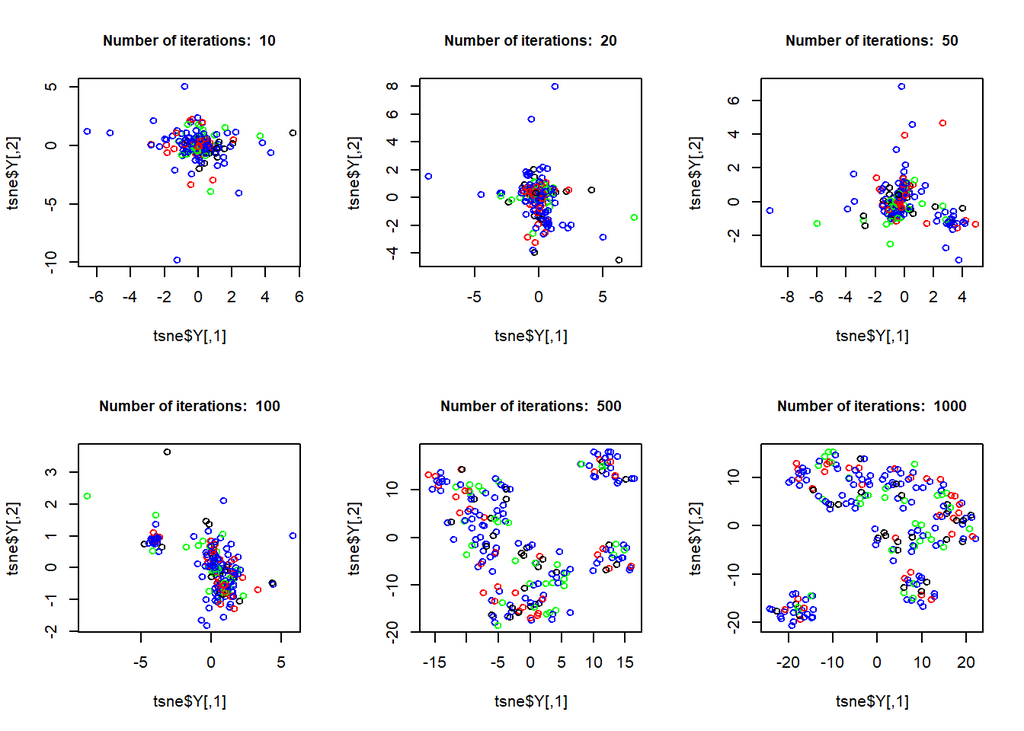

```r
set.seed(27)

par(mfrow=c(2,3))

iterations_choice <- c(10, 20, 50, 100, 500, 1000)

for (i in iterations_choice){
  tsne <- Rtsne(data_unique2,
                dims = 2,
                perplexity=10,
                verbose=TRUE,
                max_iter = i)
  plot(tsne$Y,
       main = paste("Number of iterations: ", i),
       col=colors[row_label],
       cex = 0.9,
       cex.main = 0.9)
}
```

**What we get? (Interpretation)**

## **LESSON 04 / 11.10.2019**

### SELF-ORGANIZING MAPS (SOM)

The method of Self-Organizing Maps (SOM) is a “machine learning” approach that is commonly used for clustering data sets in which the membership of the training data vectors in some prespecified number of groups G is not known. Self-organizing maps differ from other artificial neural networks as they apply competitive learning (tune neurons location iteratively based on the input and make them compete between each other). Trained SOMs classify inputs by finding the node with the closest distance to the input.

**Description:**

- Unsupervised
- Parametric
- Non-Linear
- Type of artificial neural network
- Somewhat similar to K-means (SOMs with a small number of nodes behave similar to K-means)
- Somewhat similar to PCA (can be considered a nonlinear generalization of PCA)

**Functionality:**

- Reduces the dimensionality of a dataset (similar to PCA and tSNE)
- Like most artificial neural networks, SOMs operate in two modes: training and mapping
- Trains a neural network such that parts of it become specifically responsive to certain input patterns
- Produces a low-dimensional, discrete representation (=map) of the input space of the training samples
- Mapping from a higher-dimensional input space to a lower-dimensional map space
  - Uses competitive learning (unlike other artificial neural networks, that use error correction learning like backpropagation & gradient descent)
  - Trained SOMs classify inputs by finding the node with the closest distance (smallest metric) to the input

**Aim:**

- SOMs are useful for visualization by creating low-dimensional views of high-dimensional data.

**Fields of application:**

- Market segmentation
- Medical examination (e.g. tumour detection)
- –> SOMs might perform better than other methods in certain situations (e.g. high dimensions)

**Further information:**

- Difference between SOM and k-means
  - Neurons ~ correspond to centroids in k-means
  - k-means centroids are independent between each other
  - Neurons in SOMs influence each other
  - SOMs can be seen as a constrained form of K-means
- Difference between SOM and PCA
  - Iterative procedure organizes neurons location (through node’s weight) on a low-dimensional space
  - This forms a coordinate system to classify input data, which is similar to PCA

#### Self-Organizing Maps (SOM) with basic plots

**What we do? (Code)**

We create the following 4 SOM-plots:

- Change-Plot: Shows the mean distance to the closest codebook vector during training
- Count-Plot: Shows the number of objects mapped to the individual units. Empty units are depicted in gray
- Mapping-Plot: Shows where objects are mapped
- Dist.neighbours-Plot: Shows the sum of the distances to all immediate neighbours. Units near a class boundary can be expected to have higher average distances to their neighbours.

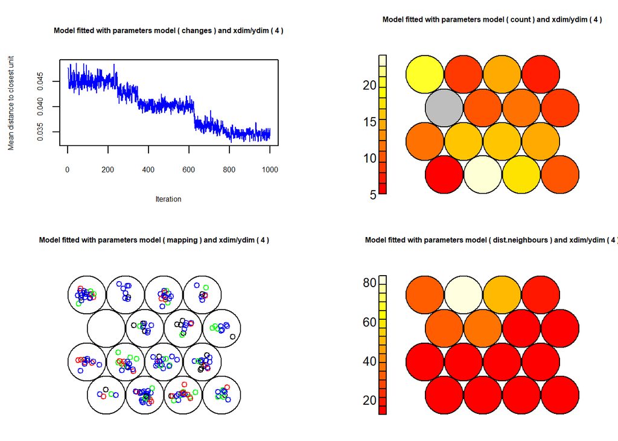

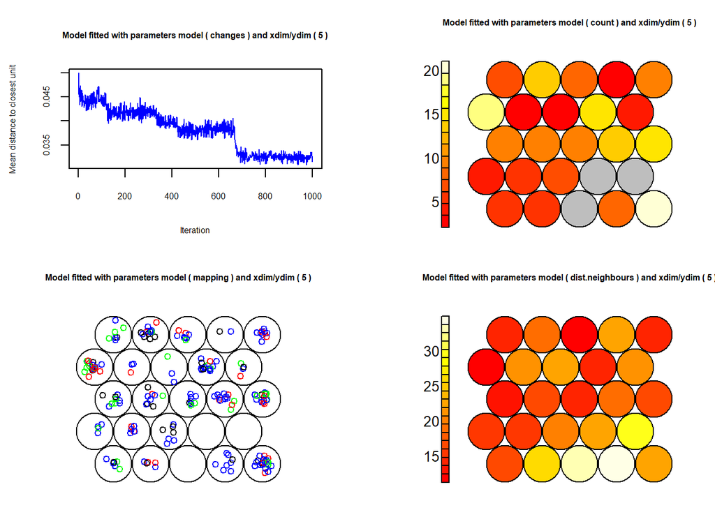

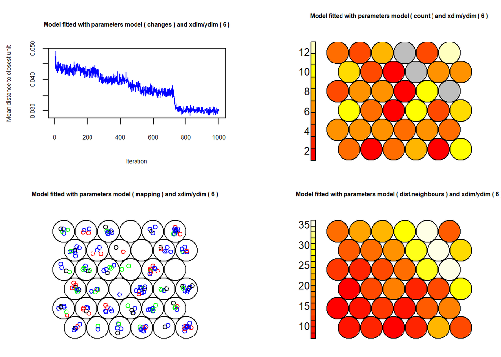

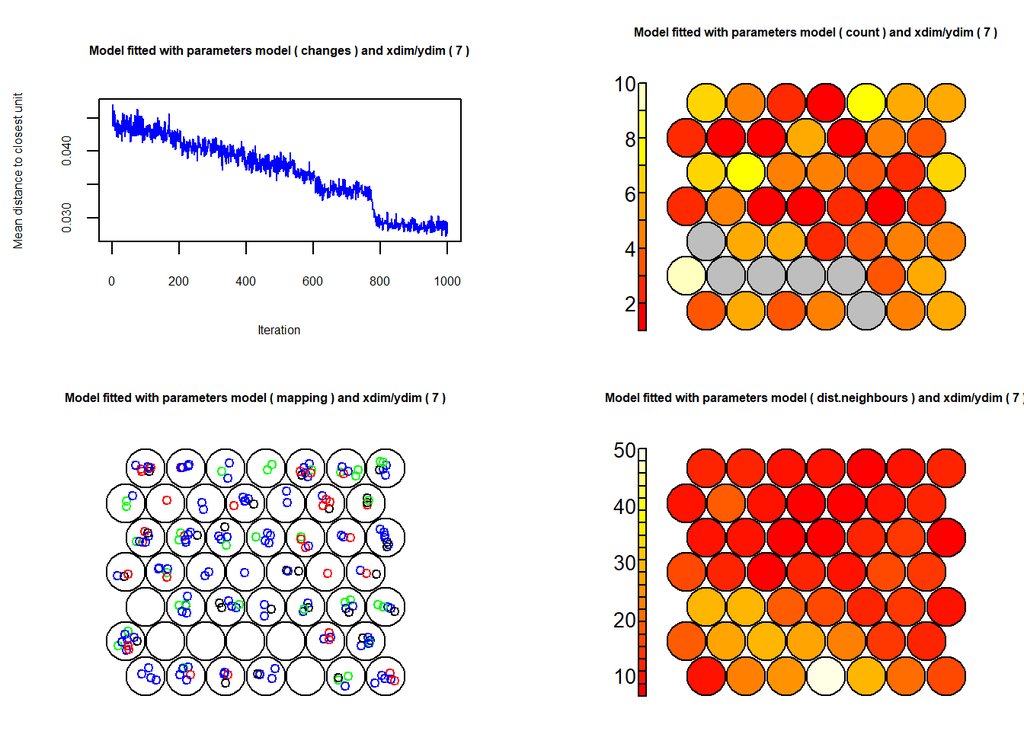

```r
set.seed(88)

par(mfrow=c(2,2), cex.main = 0.6, cex.lab = 0.6, cex.axis = 0.6)

row_label <- as.factor(rownames(selection_data_only_numerical))
colors <- c("red", "black", "blue", "green")
colors <- colors[as.numeric(data_categorical_variable)]

data_train_matrix <- as.matrix(scale(data_unique2))

som_types <- c("changes", "count", "mapping", "dist.neighbours")
som_grid_dims <- c(4, 5, 6, 7)

for (j in som_grid_dims){
  som_grid <- somgrid(xdim = j,
                      ydim = j,
                      topo="hexagonal")
  som_model <- som(data_train_matrix,
                   grid=som_grid,
                   rlen=1000,
                   alpha=c(0.05,0.01),
                   keep.data = TRUE)
  for (i in som_types){
  plot(som_model,
       type=i,
       main=paste("Model fitted with parameters model (",i,") and xdim/ydim (",j,")"),
       col=colors[row_label])
  }
}
```

**What we get? (Interpretation)**

#### Self-Organizing Maps (SOM) with heatmap

**What we do? (Code)**

Typical SOM visualizations are of heatmaps. A heatmap shows the distribution of a variable across the SOM. Therefore, we use the Property-Plot:

- Property-Plot: Properties of each unit can be calculated and shown in color code. It can be used to visualize the similarity of one particular object to all units in the map.

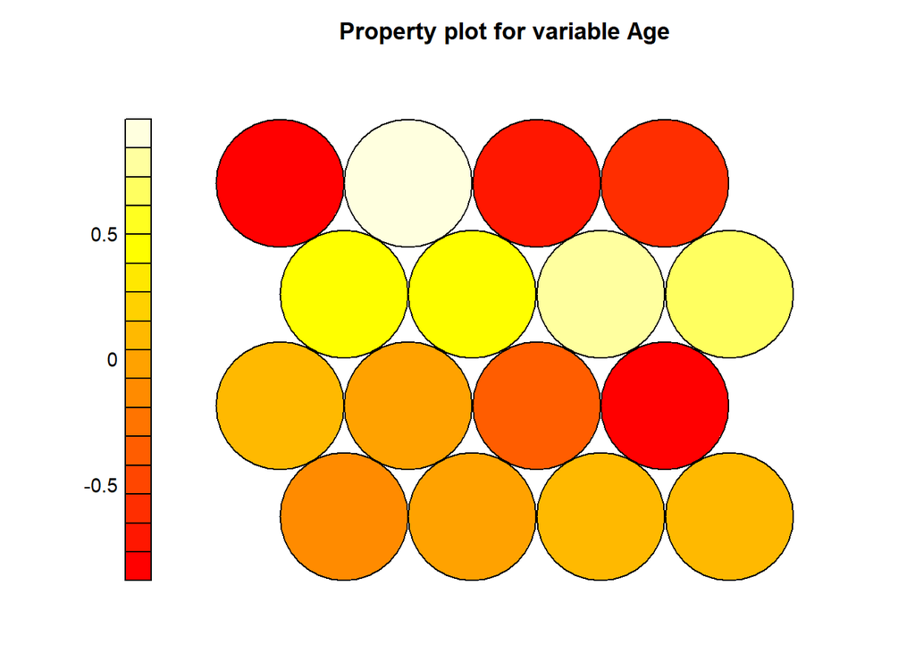

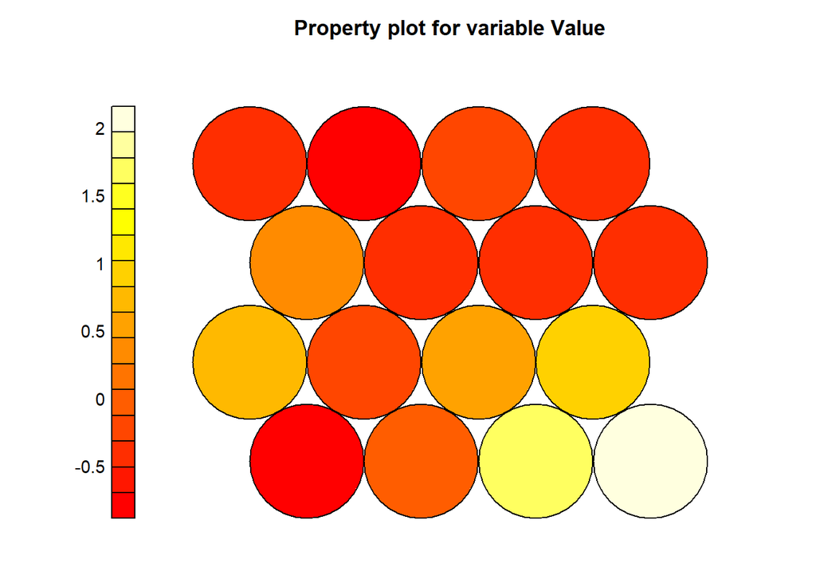

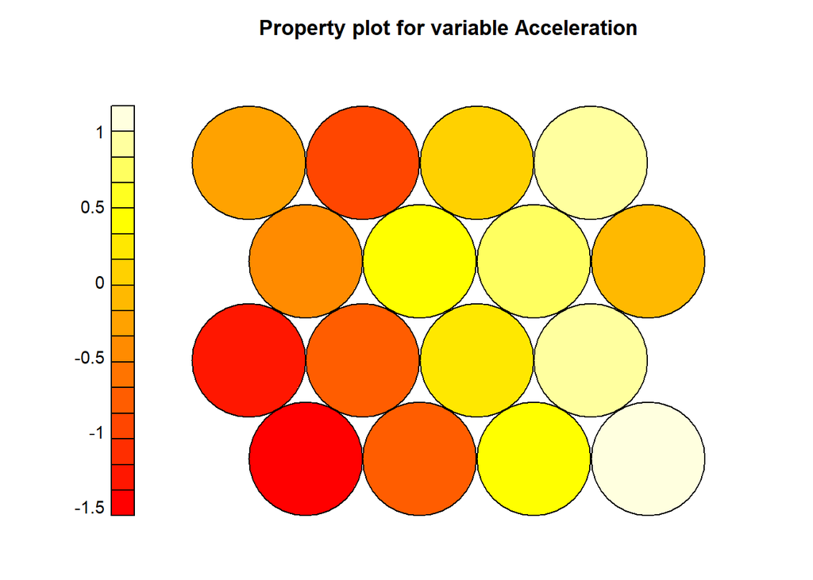

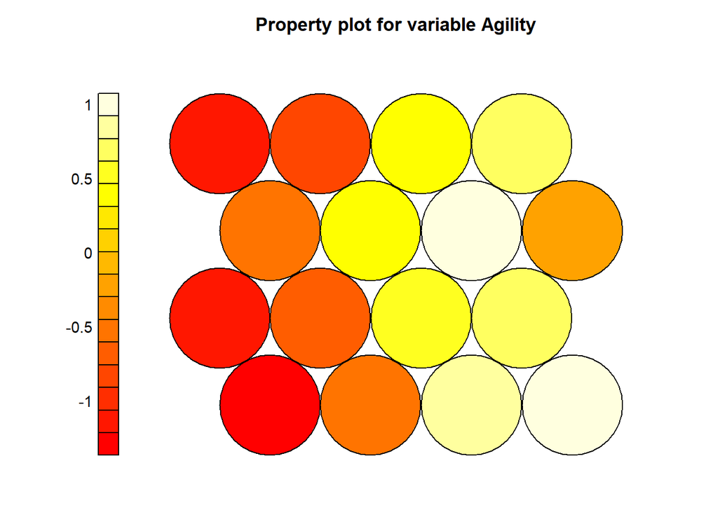

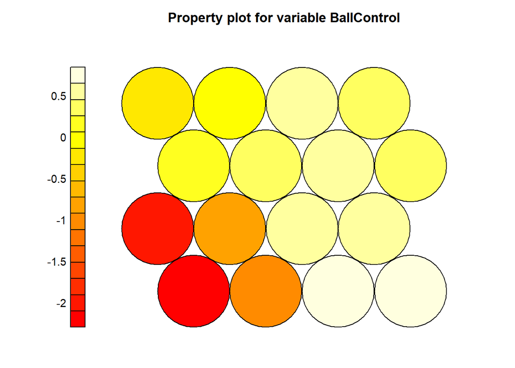

```r
set.seed(77)

par(cex = 0.9)

som_grid <- somgrid(xdim = 4,
                    ydim = 4,
                    topo="hexagonal")
som_model <- som(data_train_matrix,
                 grid=som_grid,
                 rlen=1000,
                 alpha=c(0.05,0.01),
                 keep.data = TRUE)

property_variables <- c(1,3,5,7,8)

for (i in property_variables){
  plot(som_model,
       type="property",
       property = getCodes(som_model, 1)[,i],
       main=paste("Property plot for variable",names(data_unique)[i]))
  }
```

**What we get? (Interpretation)**

#### Self-Organizing Maps (SOM) with dendrogram

**What we do? (Code)**

In the next step, we try to cluster the observations. Therefore, we isolate groups of samples with similar metrics.

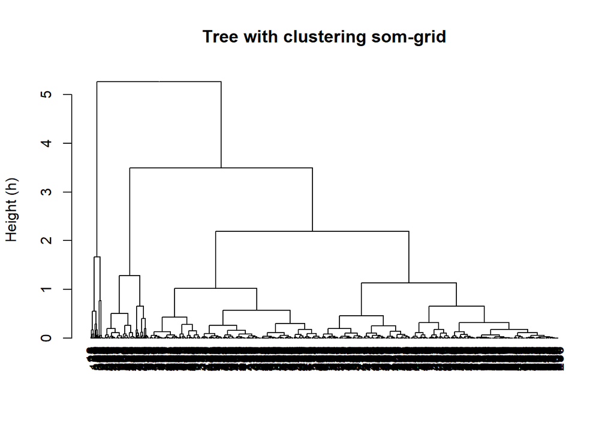

```r
set.seed(92)

som_grid <- somgrid(xdim = 4,
                    ydim = 4,
                    topo="hexagonal")
som_model <- som(data_train_matrix,
                 grid=som_grid,
                 rlen=1000,
                 alpha=c(0.05,0.01),
                 keep.data = TRUE)

tree <- as.dendrogram(hclust(dist(as.numeric(unlist(som_model$codes)))))

plot(tree,
     main = "Tree with clustering som-grid",
     ylab = "Height (h)")
```

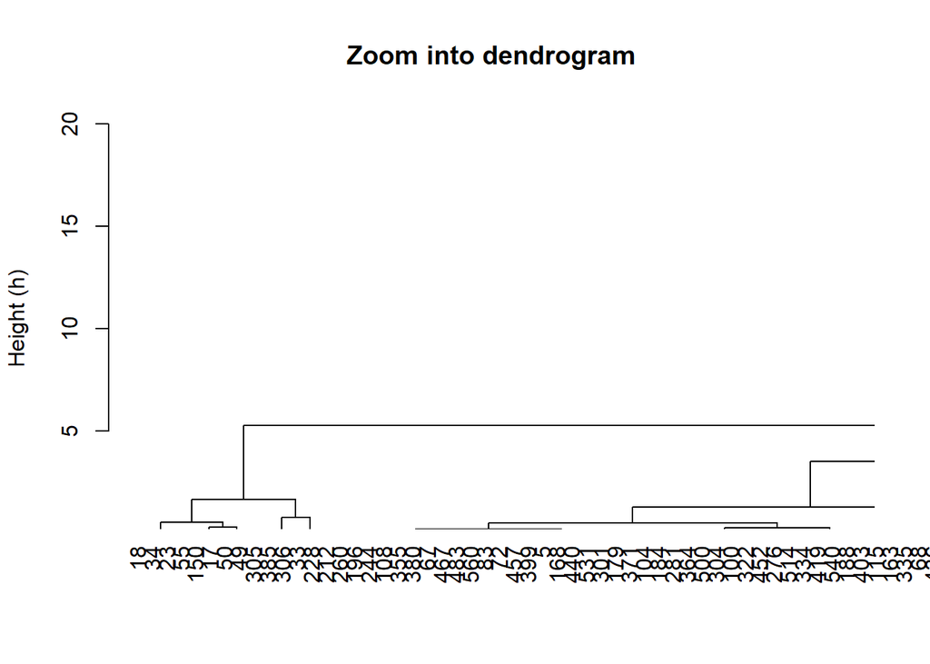

```r
plot(tree,
     main = "Zoom into dendrogram",
     ylab = "Height (h)",
     xlim = c(1, 50),
     ylim = c(1,20),
     cex = 0.6)
```

**What we get? (Interpretation)**

- The output above is a tree, which was created with SOM (clustering the observation with the defined som.grid)
- The tree allows us to isolate groups of samples with similar metrics (e.g. player 6 and 32)

#### Self-Organizing Maps (SOM) with dendrogram and clustering

**What we do? (Code)**

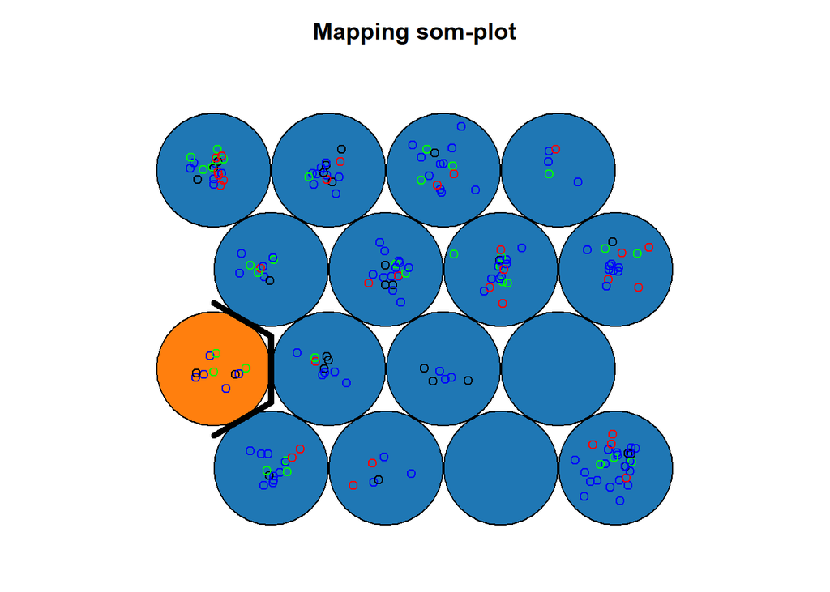

```r
set.seed(77)

som_cluster <- cutree(hclust(dist(as.numeric(unlist(som_model$codes)))), h = 3)
pretty_palette <- c("#1f77b4", '#ff7f0e', '#2ca02c', '#d62728','#9467bd', '#8c564b', '#e377c2')

plot(som_model,
     type = "mapping",
     main = "Mapping som-plot",
     bgcol = pretty_palette[som_cluster],
     col = colors[row_label],
     cex.main = 0.8)
add.cluster.boundaries(som_model,som_cluster)
```

**What we get? (Interpretation)**

- The Plot above show the Visualization of the mapping based on HC.
- Ideally, the clusters found are contiguous on the map surface.
- We can see that some of the clusters are connected. It is noticeable, that not all of the points in the clusters have the same color (representing the row label)